# TimeSeries Final Project - Apple Stock Price Prediction

Kevin and Dhruba

4/10/2021

Our Objective is to predict the stock price of Apple both individually and in conjunction with other financial and economic indicators. We believe that any business with an interest in financial markets would find a case study like this useful.

NASDAQ is the systematic technology benchmark that provides the reference as to how the apple stock price deviates from US technology benchmark

DXY is the US dollar index that measures the value of US dollar with respect to the basket of global currencies is very relevant for the apple stock as its products have the global presence and its revenue/profit depends on the currency fluctuation

Gold has traditionally been perceived as the value storage and is the counter to the inflation. Also, it indicates the state of economy in terms of its expansion or contraction. Apple products tend to sell well when the economy is in the expansion mode

Copper is famous known as Dr. Copper as it requires in electrical equipment, construction work, cable and many things that support the economic development. Therefore, the copper price indicates the economy state. In addition, Apple products too need copper; so the price of the copper has direct bearing on Apple stock

TNYR is the 10 years US bond yield and it is also called a dirty rate as it encompasses many things such as inflation expectation, market condition, currency valuation and so forth. Importantly, it is used as the proxy for the risk free rate, which is used in turn to calculate the return on equity.

CQQQ is the Invesco ETF, mimicking Chinese technology stocks. China is the big market for Apple products; therefore benchmarking Chinese technology provides another angle in evaluation Apple stock.

CAC40 is the Paris based European stock index. The same notion for which we have included CQQQ is applicable here too.

WTI has a high volatility and most cases the inflation (core + energy) is impacted by energy price as the core inflation does not fluctuate much. Therefore, the inclusion of WTI takes care of effect of energy price volatility

We have taken the adjusted close price of each parameter as it encapsulates the price volatility of a trading day. Also converted price to numerical price.

```
##        Date    Open    High    Low   Close Adj.Close    Volume
## 1 3/19/2015 32.1875 32.3125 31.850 31.8750  29.10764 183238000
## 2 3/20/2015 32.0625 32.1000 31.290 31.4750  28.74237 274780400
## 3 3/23/2015 31.7800 31.9625 31.630 31.8025  29.04143 150838800
## 4 3/24/2015 31.8075 32.0100 31.640 31.6725  28.92272 131369200
## 5 3/25/2015 31.6350 31.7050 30.845 30.8450  28.16706 206620800
## 6 3/26/2015 30.6900 31.2200 30.650 31.0600  28.36340 190291600
```

```
##        Date      Open      High       Low     Close Adj.Close Volume
## 1 3/19/2015 97.800003 99.459999 97.209999 99.099998 99.099998      0
## 2 3/20/2015 99.040001 99.120003 97.449997 97.910004 97.910004      0
## 3 3/22/2015      null      null      null      null      null   null
## 4 3/23/2015 97.800003 98.239998 96.830002 97.029999 97.029999      0
## 5 3/24/2015     96.93 97.379997 96.389999 97.190002 97.190002      0
## 6 3/25/2015 97.220001 97.300003 96.540001 96.980003 96.980003      0
```

Using Date as the index to join parameters to create a dataset. TNYR and DXY do not exactly follow US trading days as US treasuries and dollars are traded across the globe and their weekdays are a bit different from US. Similarly, Chinese and European stock do not follow the same trading days as US and their holidays are different from US. However, we have used US trading days for the data merging.

There are a few NAs in WTI, Gold, Copper, TNYR and DXY becuase of the way their trading days are handle. We used the mean of the proceeding and the following day to impute the value of NAs.

```
##       Date                 APPL            NASDAQ           WTI
##  Min.   :2015-03-19   Min.   : 21.13   Min.   : 4267   Min.   :-37.63
##  1st Qu.:2016-09-15   1st Qu.: 28.33   1st Qu.: 5228   1st Qu.: 44.74
##  Median :2018-03-19   Median : 41.42   Median : 7064   Median : 51.19
##  Mean   :2018-03-19   Mean   : 50.30   Mean   : 7262   Mean   : 51.04
##  3rd Qu.:2019-09-18   3rd Qu.: 55.11   3rd Qu.: 8101   3rd Qu.: 58.36
##  Max.   :2021-03-18   Max.   :142.95   Max.   :14095   Max.   : 76.41
##       Gold          Copper           TNYR            DXY
##  Min.   :1051   Min.   :1.940   Min.   :0.499   Min.   : 88.59
##  1st Qu.:1223   1st Qu.:2.453   1st Qu.:1.639   1st Qu.: 93.96
##  Median :1287   Median :2.679   Median :2.150   Median : 96.28
##  Mean   :1371   Mean   :2.701   Mean   :2.011   Mean   : 95.94
##  3rd Qu.:1477   3rd Qu.:2.933   3rd Qu.:2.454   3rd Qu.: 97.85
##  Max.   :2052   Max.   :4.301   Max.   :3.234   Max.   :103.29
##       CQQQ            CAC40
##  Min.   : 26.29   Min.   :3755
##  1st Qu.: 38.29   1st Qu.:4757
##  Median : 45.93   Median :5108
##  Mean   : 48.93   Mean   :5079
##  3rd Qu.: 57.13   3rd Qu.:5414
##  Max.   :108.11   Max.   :6111
```

What follows are correlation plots to understand how Apple stock is related to other prices. NASDAQ, Gold and CQQQ are highly correlated. Copper and TNYR are moderately correlated. And CAC40, DXY and WTI have a low correlation with Apple stock.

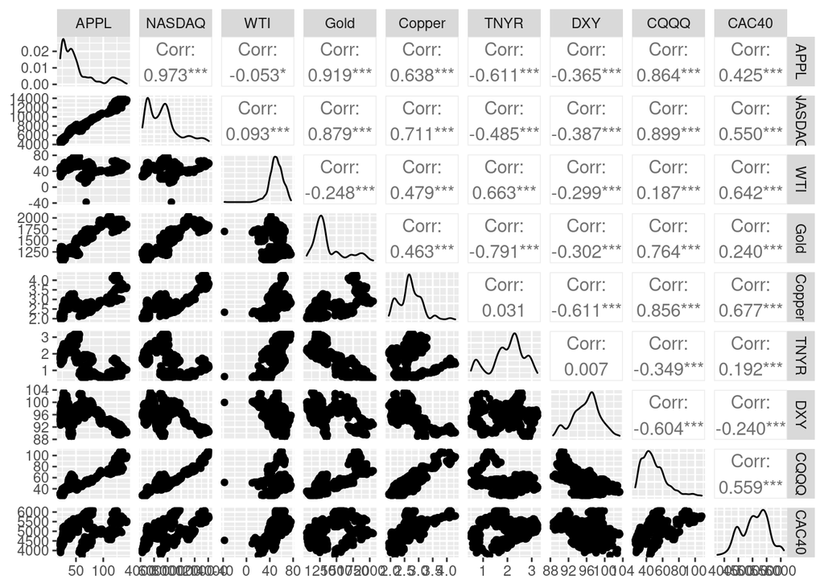

## UNIVARIATE APPLE STOCK PRICE MODELS

Checking the stationarity of the series and running the decomposition to see the trend and the seasonality

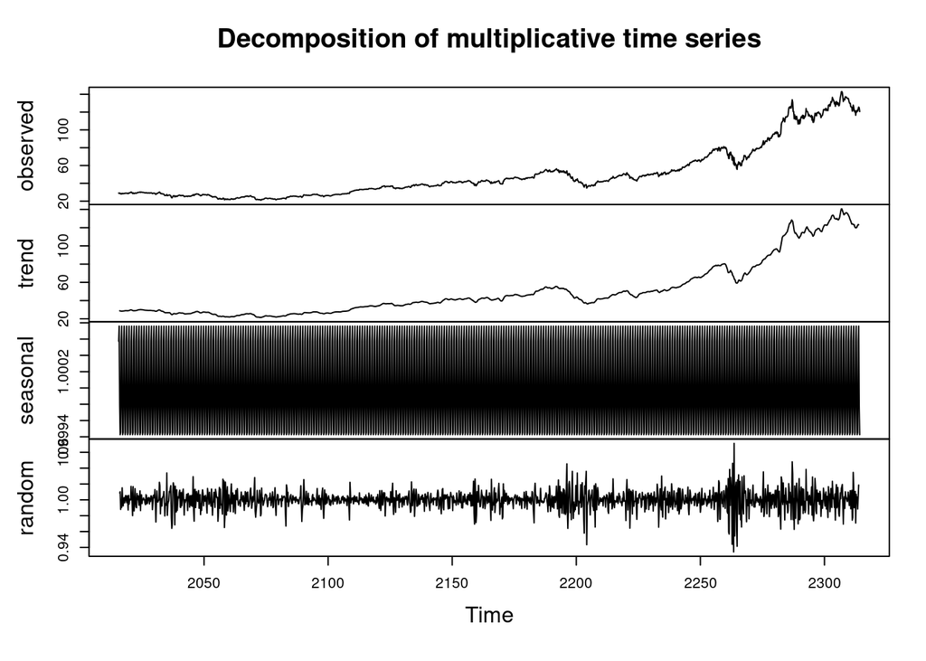

We are now ready to begin the process of identification in earnest. We first take the first difference to stationarize the series and then verify with overfitting model to see any other factor that may influence the stability of the series. We then use the ACF and PCF of this differenced series to gain initial evidence on what type of model we may be looking at. We do not note any behavior that particularly stands out, so we move onto using information criteria as a means of identifying the stationary component of our models.

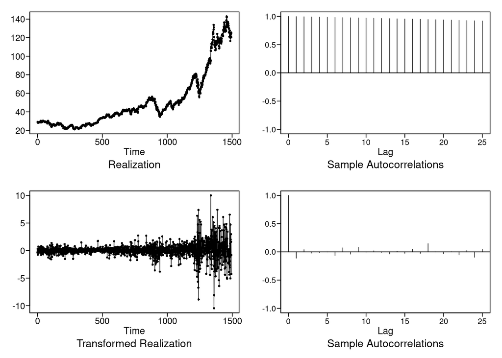

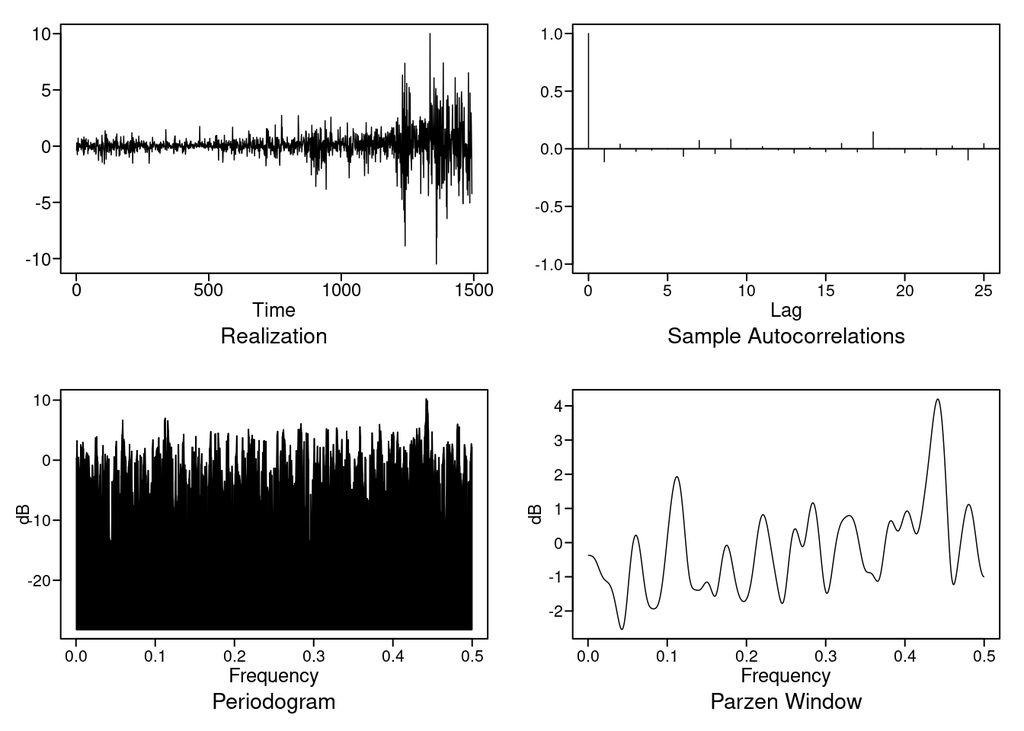

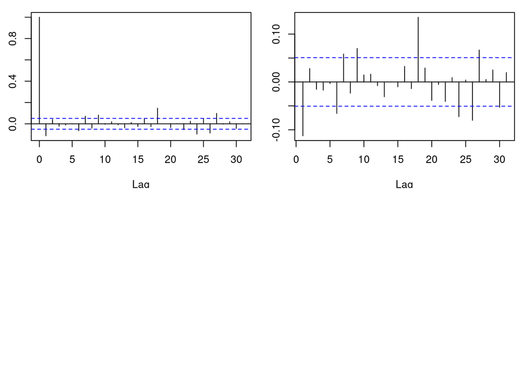

### ARIMA UNIVARIATE MODELS

Estimating the model 1 (ARIMA(4,1,2)); finding ASE and Rolling ASE for short-term (7 days) and long-term (30 days) prediction; doing the short-term and long-term forecasts

```
##
## Coefficients of Original polynomial:
## -0.5668 0.4207 0.0466 -0.0578
##
## Factor                 Roots                Abs Recip    System Freq
## 1+0.8977B             -1.1139               0.8977       0.5000
## 1-0.7258B+0.1630B^2    2.2269+-1.0851i      0.4037       0.0722
## 1+0.3949B             -2.5325               0.3949       0.5000
##
##
```

```
## [1] -0.56682747  0.42070903  0.04664157 -0.05776630
```

```
##
## Coefficients of Original polynomial:
## -0.5668 0.4207 0.0466 -0.0578
##
## Factor                 Roots                Abs Recip    System Freq
## 1+0.8977B             -1.1139               0.8977       0.5000
## 1-0.7258B+0.1630B^2    2.2269+-1.0851i      0.4037       0.0722
## 1+0.3949B             -2.5325               0.3949       0.5000
##
##
```

```
## [1] -0.4614136  0.4453040
```

```
##
## Coefficients of Original polynomial:
## -0.4614 0.4453
##
## Factor                 Roots                Abs Recip    System Freq
## 1+0.9368B             -1.0675               0.9368       0.5000
## 1-0.4754B              2.1037               0.4754       0.0000
##
##
```

```
## [1] 1.671699
```

```
## [1] 0.5232176
```

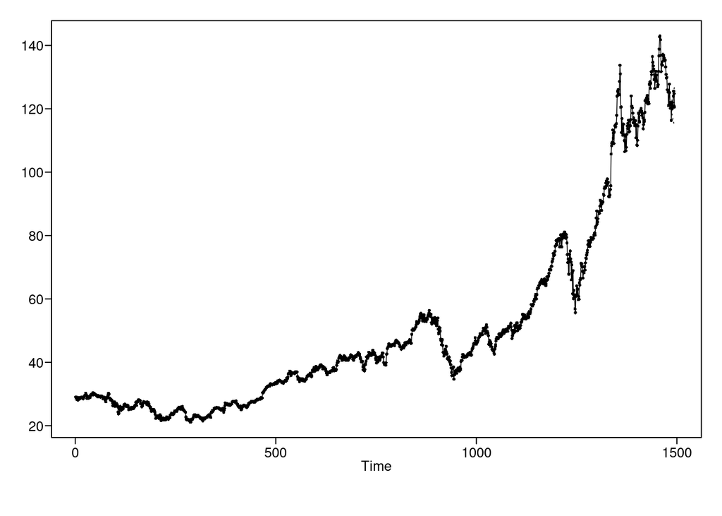

```
## [1] 120.7006 120.7138 121.0554 120.5759 121.0145 120.5794 120.9685
```

```
## [1] 7.450155
```

```
##  [1] 0.15223921 0.19826042 0.17110558 0.07065915 0.03083940 0.03227727
##  [7] 0.13398209 0.10020685 0.01160157 0.02946970 0.01709444 0.01700330
## [13] 0.11388685 0.07715498 0.11887905 0.08440738 0.24203371 0.15292434
## [19] 0.22546028 0.27479938 0.34434076 0.52569620 0.52530970 0.39587666
## [25] 0.42645040 0.84743534 2.90855290 1.80227112 0.69889797 0.73624031
## [31] 0.51793228 0.61808509 1.10643116 2.68270855 2.61255371 0.39115583
## [37] 0.64552861 1.29677146 1.22154043 1.74668526 1.99680966 1.68687980
## [43] 1.59638374 0.59538164
```

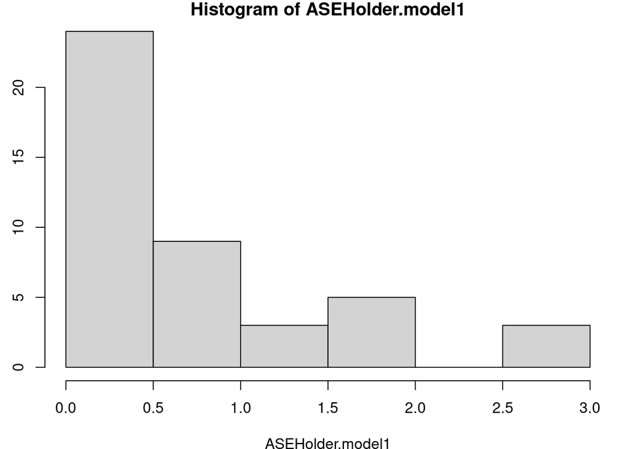

```
##    Min. 1st Qu.  Median    Mean 3rd Qu.    Max.
##  0.0116  0.1176  0.3935  0.6859  0.9122  2.9086
```

```
## [1] 0.6859137
```

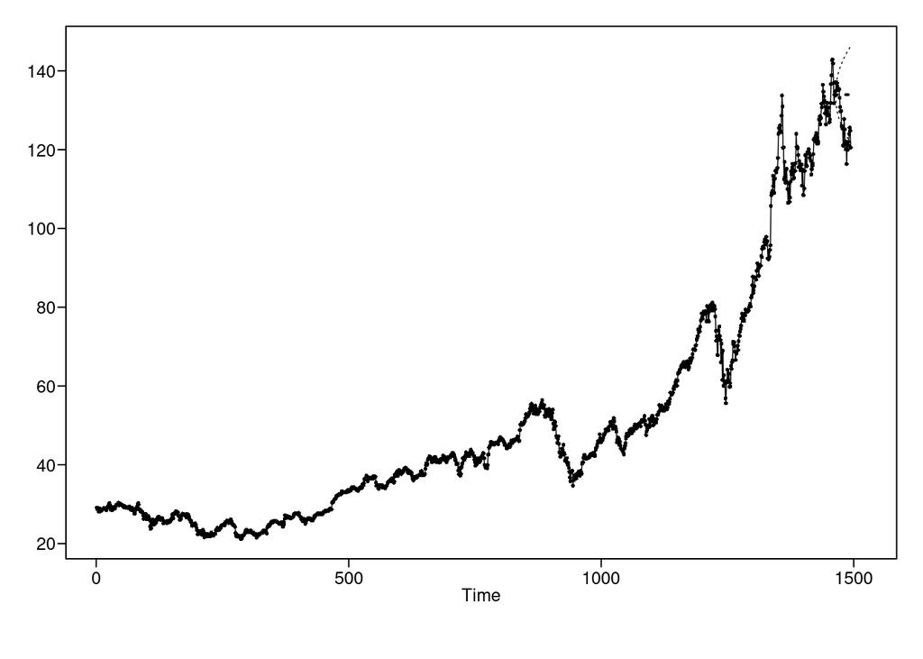

```
##  [1] 134.0048 133.8865 133.9669 133.9445 133.9703 133.9568 133.9696 133.9592
##  [9] 133.9683 133.9602 133.9674 133.9609 133.9667 133.9615 133.9662 133.9620
## [17] 133.9658 133.9624 133.9654 133.9627 133.9651 133.9629 133.9649 133.9631
## [25] 133.9647 133.9633 133.9646 133.9634 133.9645 133.9635
```

```
## [1] 87.97692
```

```
##  [1] 0.8582411 0.8259906 0.6580975 0.4554823 0.3428801 0.3041803 0.5354455
##  [8] 0.5025740 0.3458587 0.3336629 0.4526645 0.4452590 0.6127113 0.5438999
## [15] 0.9824910 1.1031381 1.6978043 1.6900203 1.5709380 1.2676064 1.5830647
```

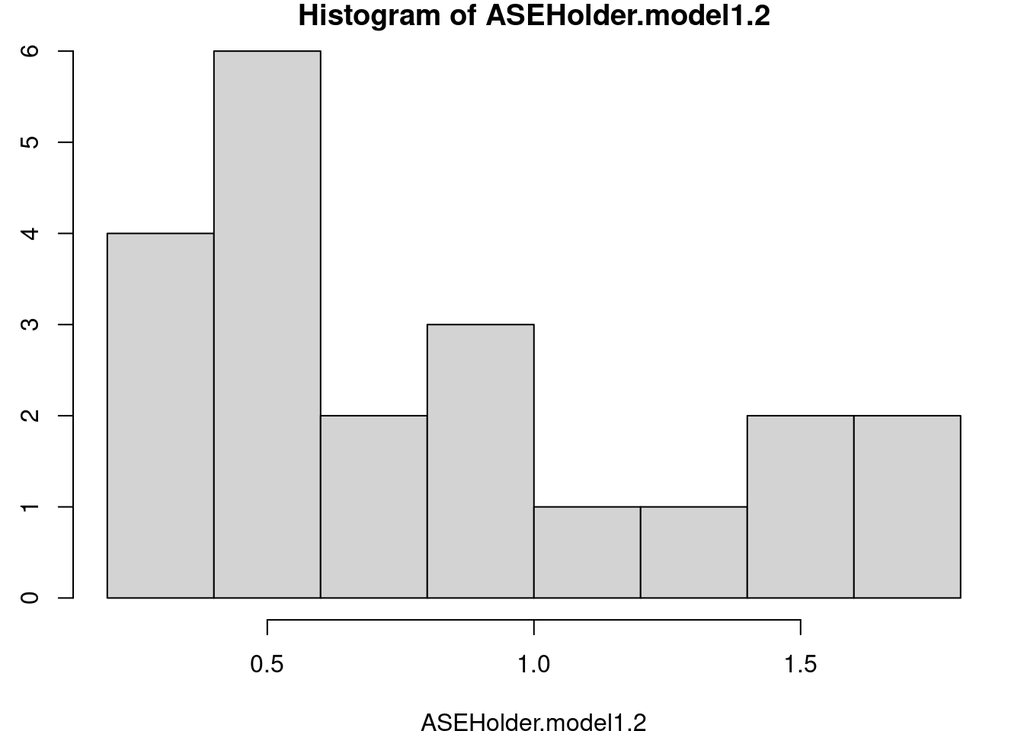

```
##    Min. 1st Qu.  Median    Mean 3rd Qu.    Max.
##  0.3042  0.4527  0.6127  0.8149  1.1031  1.6978
```

```
## [1] 0.8148576
```

```
## [1] 120.4151 120.6851 120.3332 120.8852 120.4435 120.8941 120.4990
```

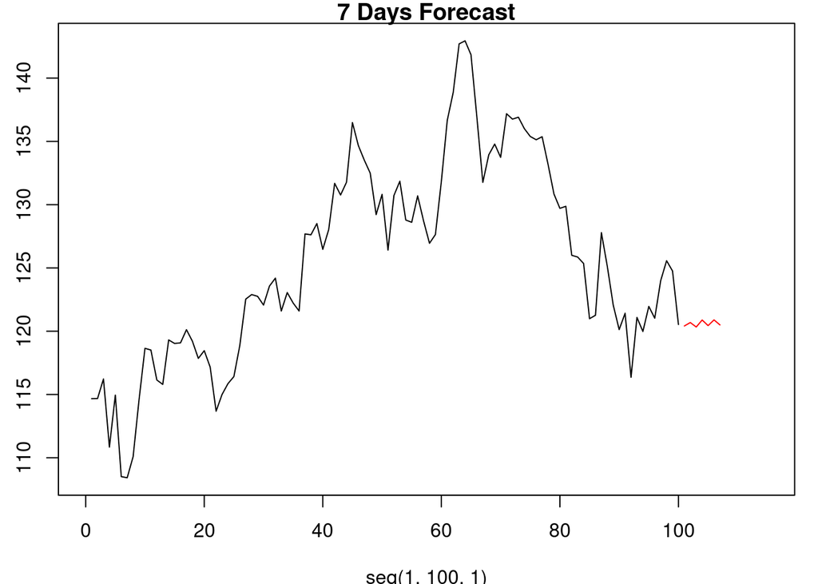

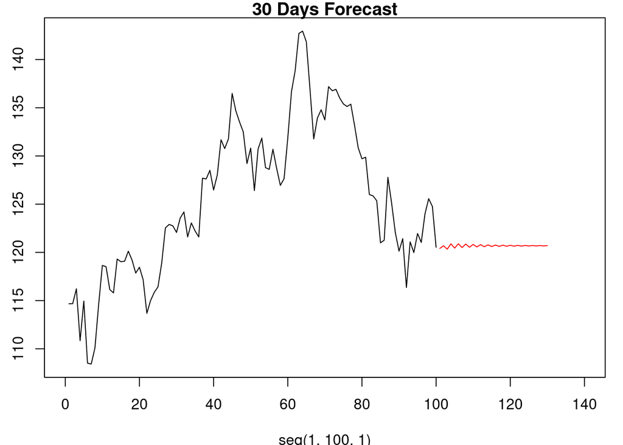

Estimating the model 2 (ARIMA(5,1,2)); finding ASE and Rolling ASE for short-term (7 days) and long-term (30 days) prediction; doing the short-term and long-term forecasts

```
##
## Coefficients of Original polynomial:
## -0.0428 0.9440 0.0785 -0.0466 0.0438
##
## Factor                 Roots                Abs Recip    System Freq
## 1-0.9893B              1.0108               0.9893       0.0000
## 1+0.8749B             -1.1430               0.8749       0.5000
## 1+0.4907B             -2.0379               0.4907       0.5000
## 1-0.3335B+0.1031B^2    1.6170+-2.6612i      0.3211       0.1631
##
##
```

```
##
## Coefficients of Original polynomial:
## -0.8502 -0.0555 -0.0066 -0.0256 0.0682
##
## Factor                 Roots                Abs Recip    System Freq
## 1+1.4459B+0.5894B^2   -1.2266+-0.4383i      0.7677       0.4454
## 1-0.1510B+0.2603B^2    0.2901+-1.9386i      0.5102       0.2264
## 1-0.4447B              2.2489               0.4447       0.0000
##
##
```

```
## [1] 0.06179226 0.91457617
```

```
##
## Coefficients of Original polynomial:
## -0.7585
##
## Factor                 Roots                Abs Recip    System Freq
## 1+0.7585B             -1.3183               0.7585       0.5000
##
##
```

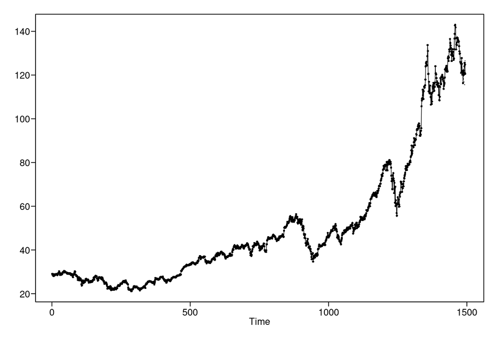

```
## [1] 7.714366
```

```
##  [1] 0.15704613 0.13353724 0.95295078 0.27191940 0.19966803 0.05508831
##  [7] 0.73769707 0.14766975 0.03989452 0.10758100 0.03710428 0.06461793
## [13] 0.10404875 0.07127312 0.12034289 0.33404012 1.06956530 0.46625264
## [19] 1.28336363 0.72822449 1.68368618 0.66958990 0.57551602 2.00084044
## [25] 0.43021579 0.70384642 7.23984810 2.19296418 0.34782989 0.53398570
## [31] 0.78651985 0.54201763 3.56277979 5.83414993 4.09594878 0.97613666
## [37] 0.68226505 2.10876011 2.99398310 0.75620157 1.58011900 3.14168445
## [43] 0.86032003 0.31585202
```

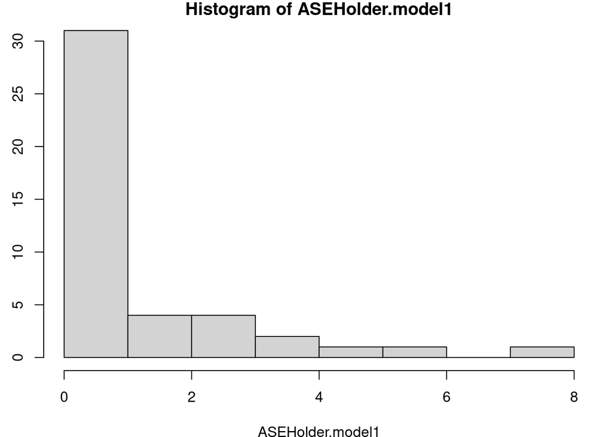

```
##    Min. 1st Qu.  Median    Mean 3rd Qu.    Max.
##  0.0371  0.1890  0.6759  1.1749  1.3576  7.2398
```

```
## [1] 1.174931
```

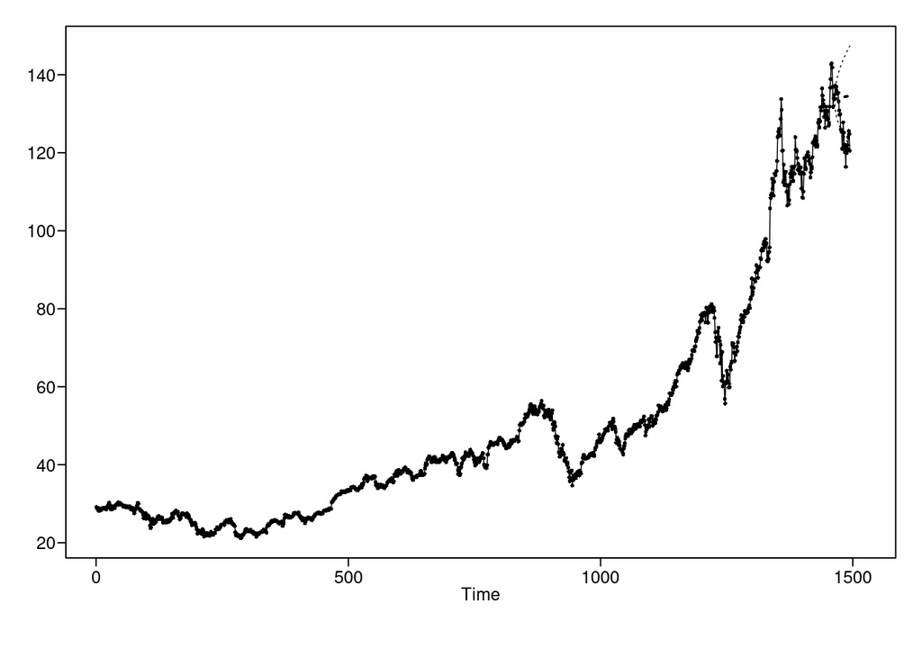

```
##  [1] 133.8997 133.7869 133.9158 133.9023 133.9623 133.9694 134.0138 134.0295
##  [9] 134.0679 134.0869 134.1218 134.1425 134.1750 134.1967 134.2272 134.2495
## [17] 134.2784 134.3010 134.3287 134.3514 134.3779 134.4006 134.4262 134.4488
## [25] 134.4735 134.4959 134.5198 134.5419 134.5651 134.5869
```

```
## [1] 94.23455
```

```
##  [1]  2.9309185  0.4444674  7.9187041  2.4285218  2.7459109  0.9588753
##  [7]  5.7698554  0.8544180  0.9223872  3.1125683  0.9127714  0.4831198
## [13]  0.5523724  0.4602157  2.0980594  4.5032333 10.3856042  5.3638086
## [19] 13.1534222  7.0399694 15.1559295
```

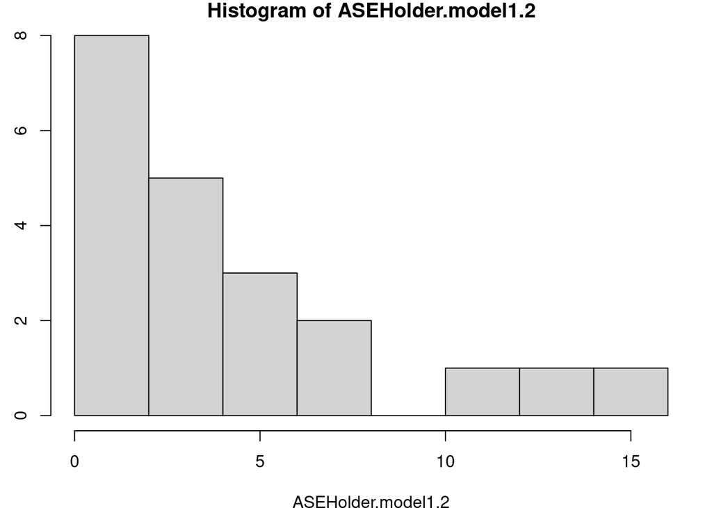

```
##    Min. 1st Qu.  Median    Mean 3rd Qu.    Max.
##  0.4445  0.9128  2.7459  4.1998  5.7699 15.1559
```

```
## [1] 4.199768
```

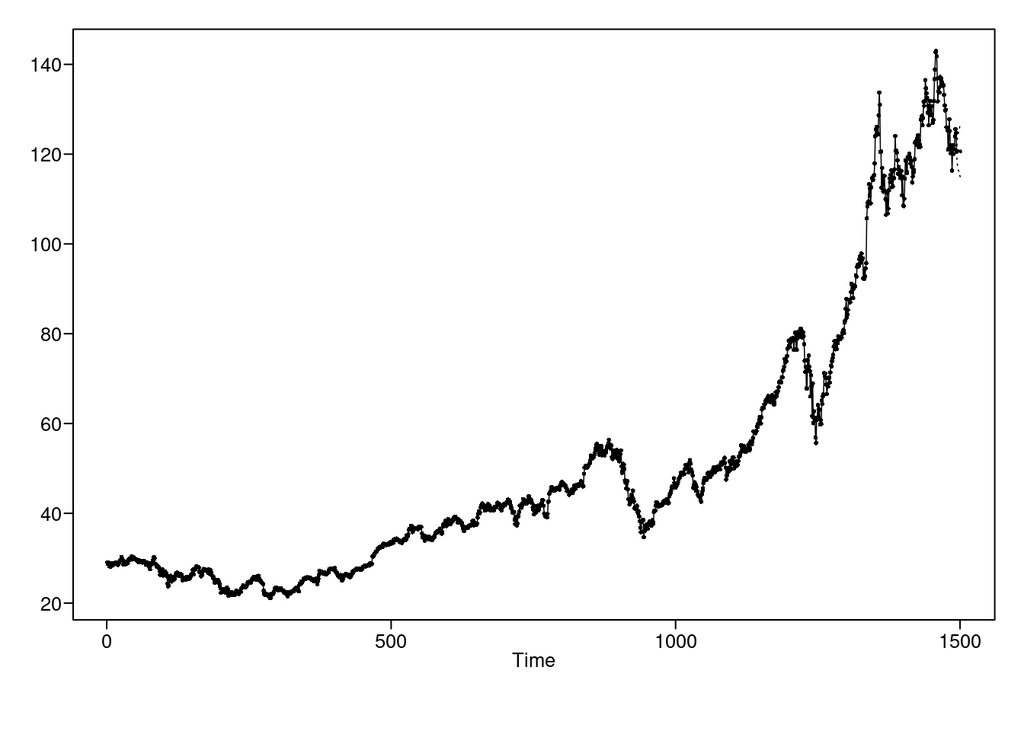

```
## [1] 120.4222 120.7961 120.4531 120.9740 120.4770 120.9409 120.5252
```

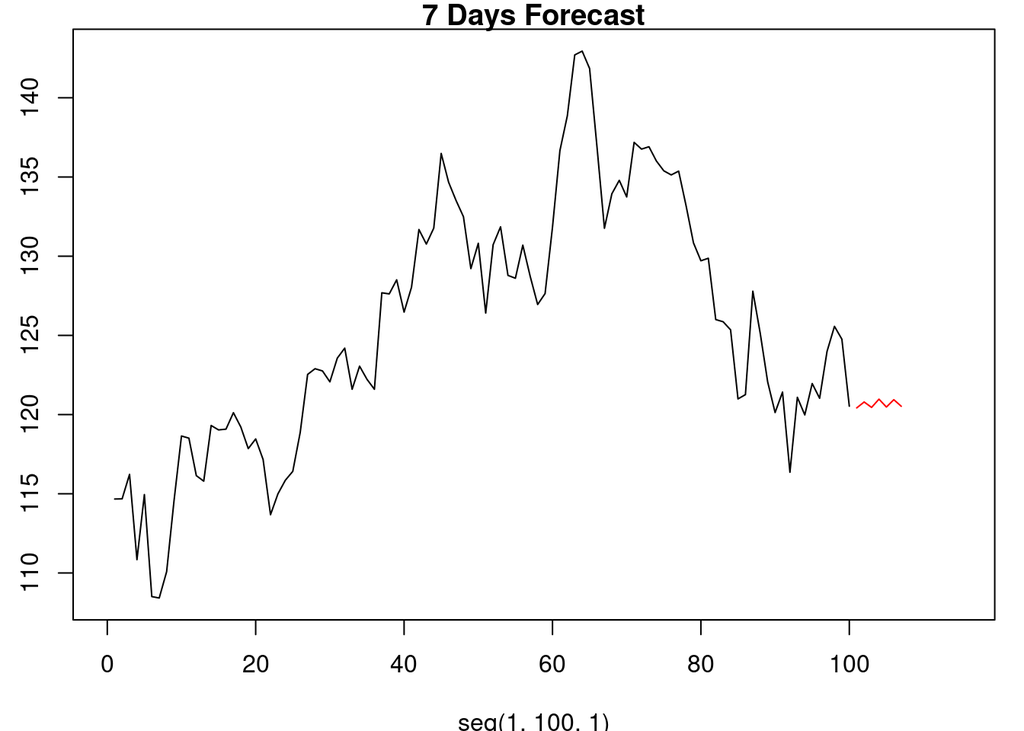

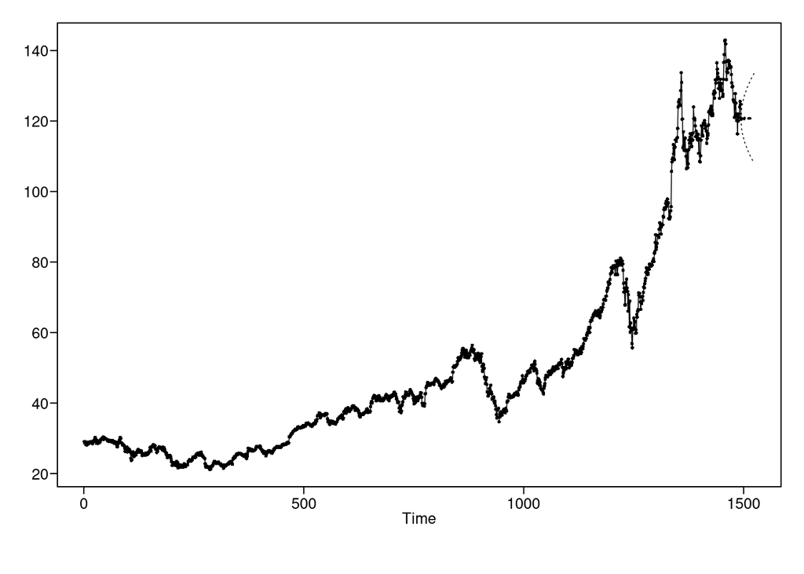

```
##  [1] 120.4222 120.7961 120.4531 120.9740 120.4770 120.9409 120.5252 120.9026
##  [9] 120.5764 120.8706 120.6194 120.8464 120.6544 120.8293 120.6829 120.8176
## [17] 120.7063 120.8101 120.7257 120.8059 120.7420 120.8041 120.7559 120.8041
## [25] 120.7679 120.8055 120.7785 120.8080 120.7879 120.8111
```

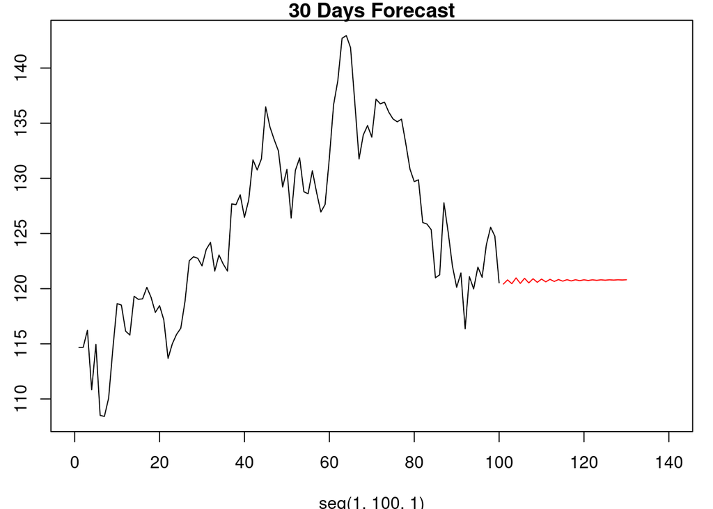

### UNIVARIATE MODEL: Signal plus noise model

We first construct the deterministic component of our model and then treat the residuals as a stationary random process. We make use of lung-box test to see if the residuals are whitened by the deterministic component and then we move on to modeling the residuals after finding no evidence to suggest that they have been whitened.

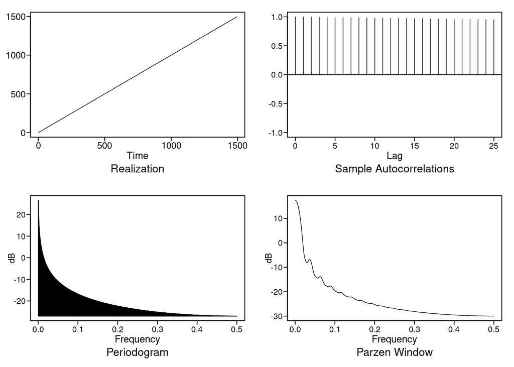

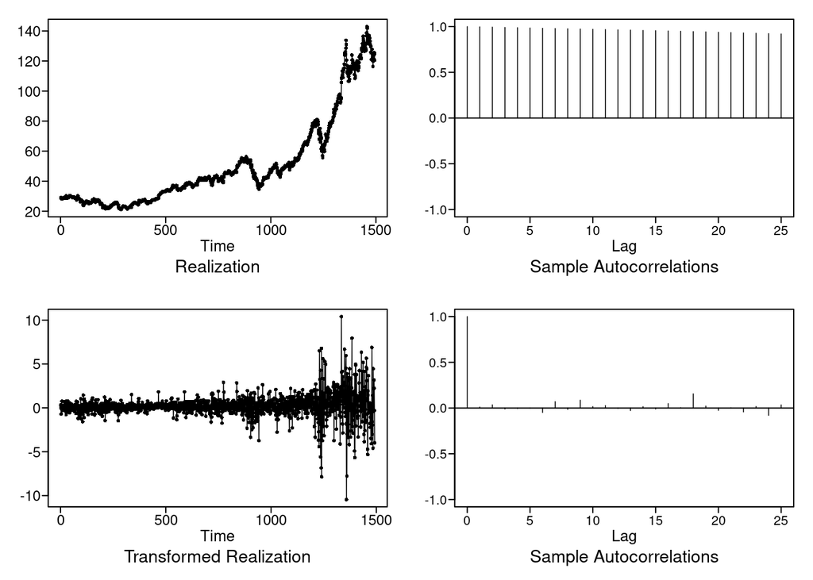

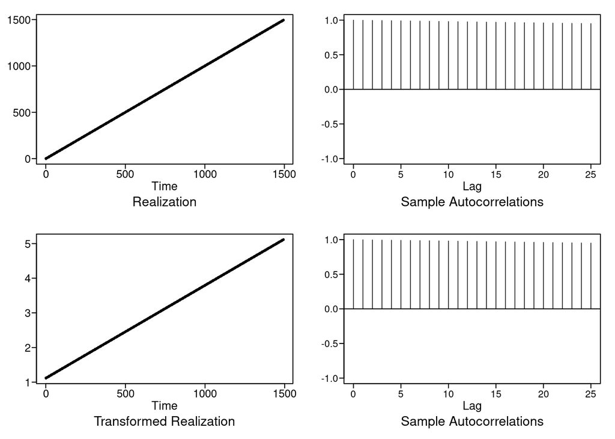

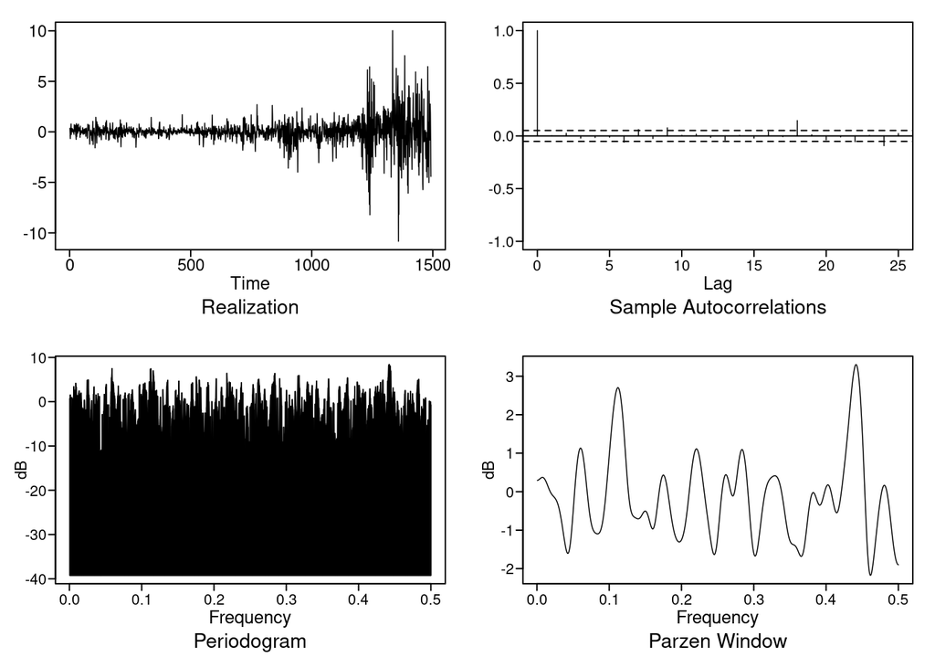

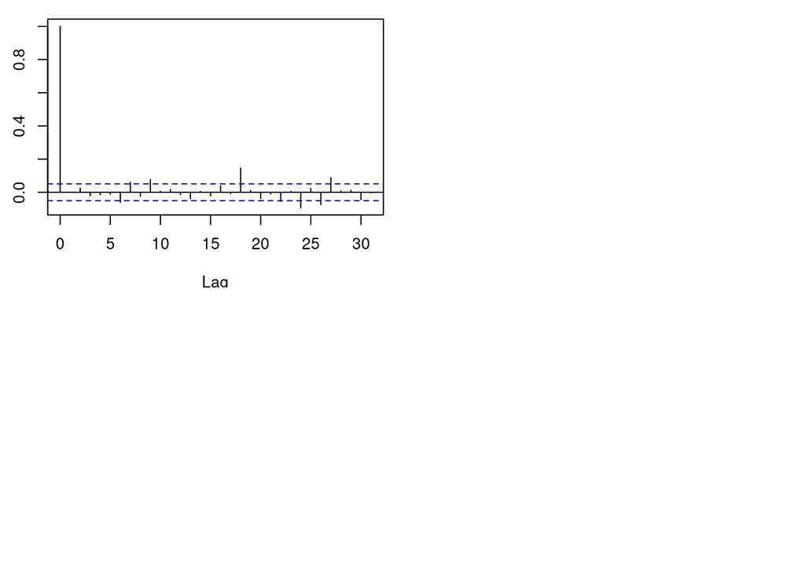

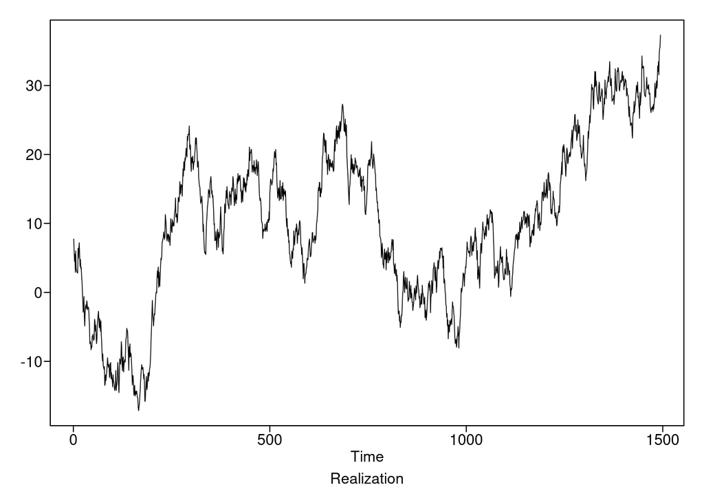

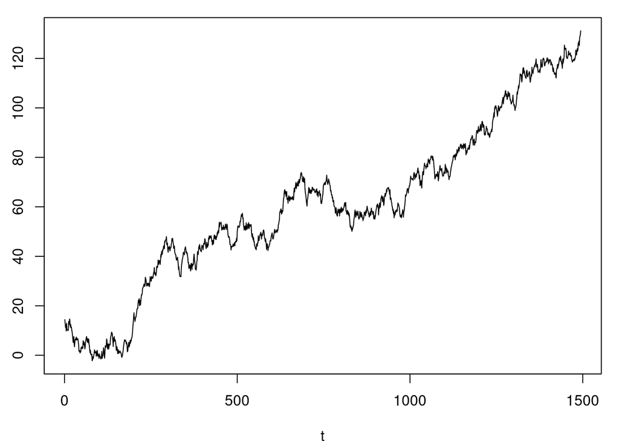

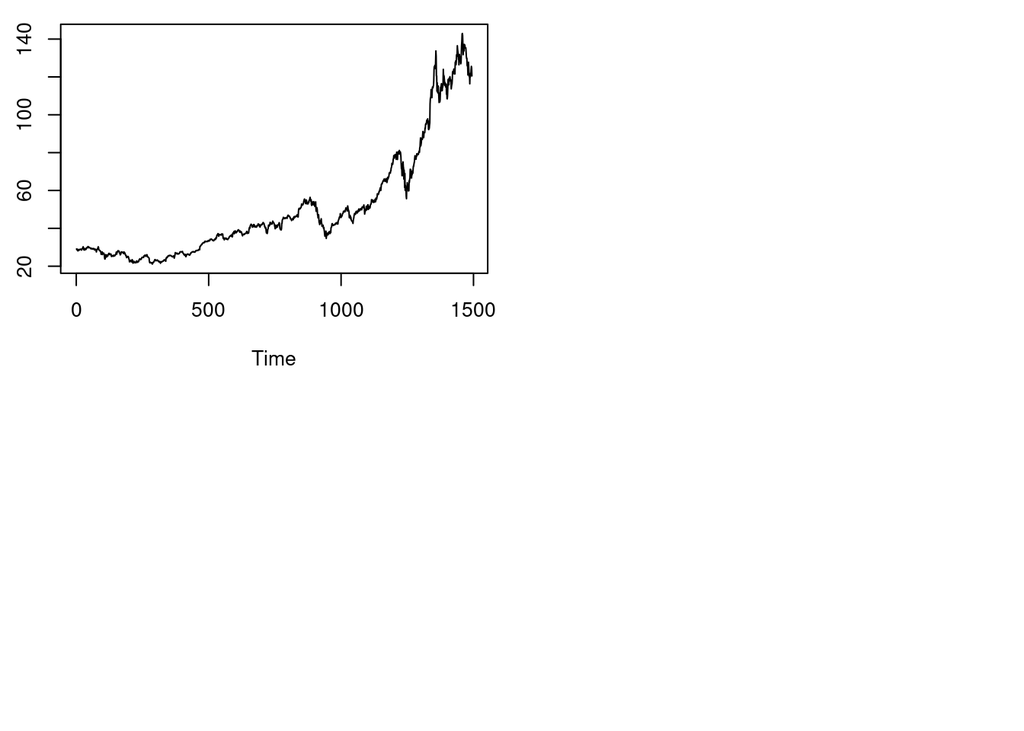

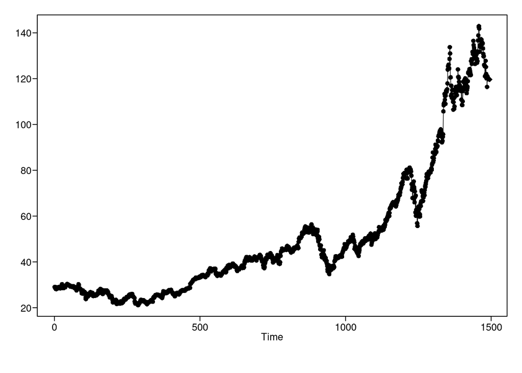

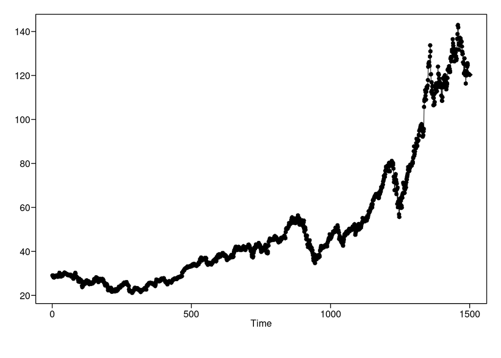

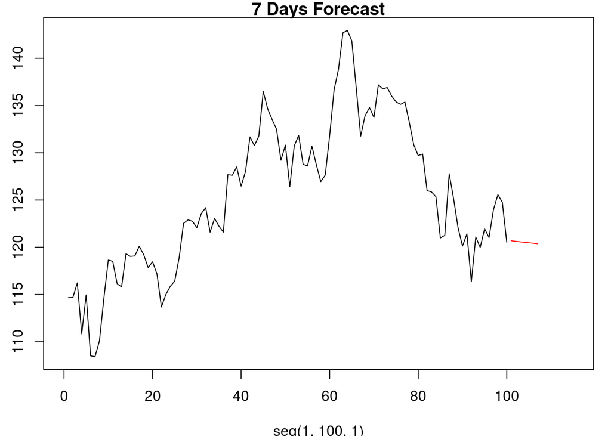

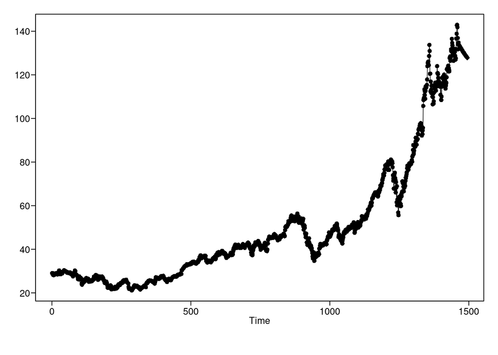

[2 more figures not shown]

### NEURAL NET UNIVARIATE MODEL